# Replication of Capacity for Visual Features in Mental Rotation (Experiment 1a) by Y. Xu & S. L. Franconeri (2015, Psychological Science)

Andrew Lampinen (lampinen@stanford.edu)

January 28, 2016

## Introduction

In their study, Xu & Franconeri tested the ability of subjects to maintain visual information about an object while performing a mental rotation of it, or in a control no-rotation condition. In both cases, they were also performing a verbal suppression task to control for use of verbal encoding. The object consisted of a cross with four colored bars, which sometimes switched. They found that performing mental rotation significantly impaired ability to detect these bar swaps. We attempted to replicate this finding on Amazon’s Mechanical Turk.

## Methods

### Power Analysis

Using G*Power, we ran an analysis based on the effect-size statistic found by the authors, $\eta^2 = 0.74$, and computed the post-hoc power for the original study to be 0.92. Thus, we originally intended to run the study with 12 subjects, as in the original paper.

However, we have reduced the amount of data collected per subject from 5 blocks to 2, as noted in the Procedure section. Thus we increased our sample size to 30 participants, in order to collect the same total amount of data. We further chose to collect an additional 5% more (2 more subjects), in anticipation of dropouts and exclusions reducing our sample size.

### Planned Sample

Our sample will be taken from Mechanical Turk, which has a broader population sample than standard college-student based studies, but generally produces equally reliable data (Buhrmester, Kwang, and Gosling, Perspectives on Psychological Science, 2011).

### Materials

In the original experiment:

> “The experiment was conrolled by a PC running SR Research Experiment Builder (SR Research Ltd., Mississauga, Ontario, Canada). The display subtended 32.6° × 24.4° at an approximate view- ing distance of 56 cm and was presented on a 17-in. Dell E770S CRT monitor with a 75-Hz refresh rate and resolu- tion of 1,024 × 768 pixels (33.6 pixels per degree). On each trial, participants were shown an abstracted four- bond molecule: a cross with four distinctly colored parts, each 10.7° long and 2.4° wide (see Fig. 2a). The four colors were randomly assigned to the four parts without replacement. The set of colors consisted of orange (RGB values: 233,122,0), green (RGB values: 0,166,0), aqua (RGB values: 0,136,233), and magenta (RGB values: 230,0,230), and the object was presented against a dark gray (RGB values: 80,80,80) background. In the initial display, any two adjacent parts formed a 90° angle, and the whole object was tilted either 10° clockwise (50% of trials) or 10° counterclockwise (50% of trials) from the cardinal orientation.”

Unfortunately, on Mechanical Turk, we did not have direct control over the size of the participants display, their position relative to that display, etc. The experiment ran within a frame on the Mechanical Turk website, we were unable to control the display outside of this frame. However, we endeavored to reproduce the stimuli as faithfully as possible, by running an experiment in a frame with the same aspect ratio (800 x 600), and with the stimuli produced with bars 263 pixels long and 60 pixels wide, in the same proportion to the display area that they were in the original experiment. Finally, although it was not stated explicitly in the original paper, in the figures illustrating the experiment it appears the display of the cross included a dark circle that covered the center of the cross figure. We used a black circle of radius $\sqrt{2}/2$ times the width of the rectangles for this (i.e. a circle just big enough to completely cover the center).

### Procedure

The original paper’s procedures were:

> “In the object-rotation condition, trials were self-initiated and began with a cue animation showing a gray-scale pinwheel rotating for 2,400 ms; this rotation was accompanied by a continuous auditory clip of a mechanical sound mimicking a wheel rotating (Fig. 2a). The wheel rotated either clockwise or counterclockwise. Participants were instructed to think of the auditory clip as the sound that the wheel made while rotating and to remember the direction and rate of the wheel’s rotation (a constant rate). They were informed that the cumulative amount of the wheel’s angular rotation was irrelevant to the task. The to-be-rotated image was then presented statically for 500 ms, followed by a blank screen, which was presented for 800, 1,600, or 2,400 ms. Participants were instructed to pretend that a curtain dropped between them and the image, so that while the screen was blank, they would hear the mechanical sound but not see the rotating image. As soon as they heard the sound, they were to imagine the image rotating in the same direction and at the same rate as the wheel at the beginning of the trial, for as long as the mechanical sound played. They were told that at an unpredictable point, the “curtain would be raised” (though all display transitions were immediate), and another image would be revealed. Their task then was to indicate whether the image represented the same object with no feature swaps (i.e., with all colors attached to the correct postrotation parts) at the correctly rotated orientation. In the control, no-rotation condition (see Fig. 2a), the cue was a static wheel with no sound. The four-part object was then presented for 500-ms, and participants were told to remember which colors were attached to which parts; no rotation was required. The delay intervals before the test image was presented were equivalent to those in the object-rotation condition. In both conditions, the test image represented the initial object correctly on 50% of the trials, and was incorrect on the other 50% of the trials. Participants were given auditory feedback on their accuracy. To isolate processing capacity for visual representations without the aid of verbal encoding, we included a verbal suppression task in both conditions. Prior to the cue in each trial, participants were presented with four nonrepeating consonants, and they were told to rehearse the letters mentally throughout the trial. Participants’ memory for the letters was tested, unpredictably, at the end of 25% of the trials. Incorrect answers led to auditory feedback and a 3-s delay penalty, during which participants could not advance to the next trial. Participants were told that they should monitor each test object for both inaccurate orientation and color swaps within the object. The experimenter guided each participant through several sample trials (equal numbers of all trial types within the design), providing verbal feedback on the participant’s verbal responses. If the test image was an incorrect foil, the experimenter revealed whether it was an orientation foil or a feature-swap foil. After this interactive tutorial, the participant completed another set of self-paced practice trials before starting the actual experiment. In the object-rotation condition, an incorrect foil was equally likely to be a feature-swap foil (i.e., correct orientation but two colored parts swapped) or an orientation foil (i.e., wrong orientation and no color swap). In the no-rotation condition, incorrect foils were always featureswap foils. Task condition (clockwise object rotation, counterclockwise object rotation, or no rotation), testimage type (correct or incorrect), feature-swap foil (six possible foils), foil type (feature swap or orientation in the object-rotation condition; feature swap only in the norotation condition), and length of the rotation/memory interval (800, 1,600, or 2,400 ms) were fully crossed across 180 randomly ordered trials. Each participant was tested in five blocks of 36 trials. The entire experiment lasted approximately 60 min.”

### Analysis Plan

We will analyze the data following the analysis used in the original paper. We will compute the mental capacity *K* with the formula for 2-alterative forced choice given by Alvarez & Thompson (2009). We encountered a situation in our pilot where the estimate of *K* was less than zero in the rotation condition, (this will occur whenever the false positive rate is higher than the hit rate) we chose to allow these estimates to avoid breaking the assumption of t-distribution of the means. (It is not clear whether this situation arose in the original study, or what their resolution was.) We will discard participants who have less than 75% accuracy in the verbal suppression task. We will compare the groups using a one-way ANOVA on the capacity estimates for each individual, aggregated across all their trials of each type, as that appears to be the technique used in the paper.

### Differences from Original Study

1. We collected data on Amazon’s Mechanical Turk, instead of in a laboratory. This changed the sample population, and reduced control over the testing environment and the display (e.g. the subject might have completed the experiment on a 70" tv in front of them, or on a tablet on their lap). We do not expect this to have significantly altered the results, because the stimuli were correspondingly reproduced, and the viewing environment should have little effect on mental capacity. Research such as (Buhrmester, Kwang, and Gosling, Perspectives on Psychological Science, 2011) suggests that data from Mechanical Turk are reasonably reliable, and we are aware of no reason to suspect that the results would be different for this particular task.
2. We reduced the length of the study (and compensated by recruiting more participants), to make the study more appealing to Mechanical Turk workers. This necessitated reducing the original design by randomizing the choice of swap on the foil swap trials, instead of fully crossing it. We do not expect this to affect the results, since there are still a large number of trials in each experiment, and there are only six possible swaps.
3. The original study did not state how they handled out of range capacity estimates, we chose to allow these estimates to avoid breaking the statistical assumptions of the hypothesis tests. See the analysis plan section above for details.

### Our study

Our study can be done online at: https://web.stanford.edu/~lampinen/mturk/254/replication/web/replication_experiment.html

## Main Analysis

### Original results

The original paper’s results are reproduced below:

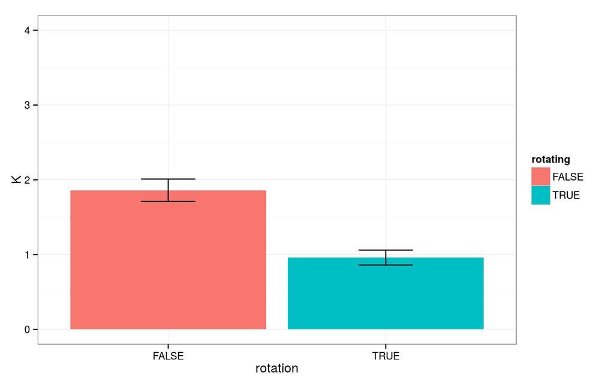

*Original test statistic:* $F (1, 11) = 32.04, p < .001$

### Our results

The plot of our result is below:

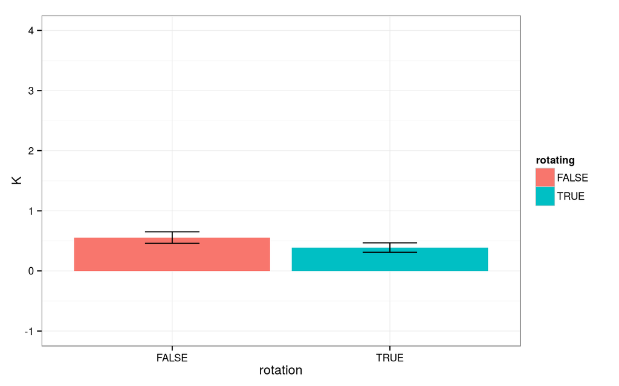

*Our test statistic for a difference between the groups:*

The value $K$ is the capacity, the estimated number of features (0-4) the subjects could retain in each condition. This test compares the mean capacity between the two conditions. $F(1,26) = 3.645357, p = 0.0673199$ (This was computed by running a paired t value on the data across the rotating and non-rotating conditions, using $F = t^2$ relation to get an $F$-statistic, and then performing the significance tests on that $F$-statistic.)

## Secondary analyses

### Accuracy-based analysis

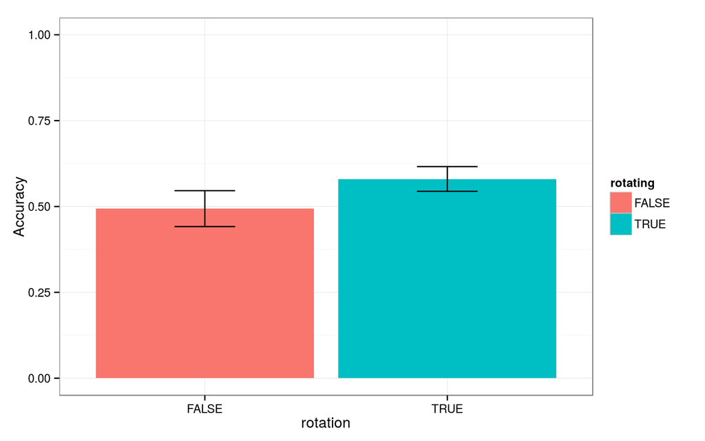

This statistic is another check of the main result that was included in the original paper, based on the accuracy (hit rate) between the conditions, rather than computed capacity: $F(1,26) = 3.1593304, p = 0.0871952$ (Computed identically to the above, except using accuracy instead of capacity.)

### Capacity analysis split by rotation_time

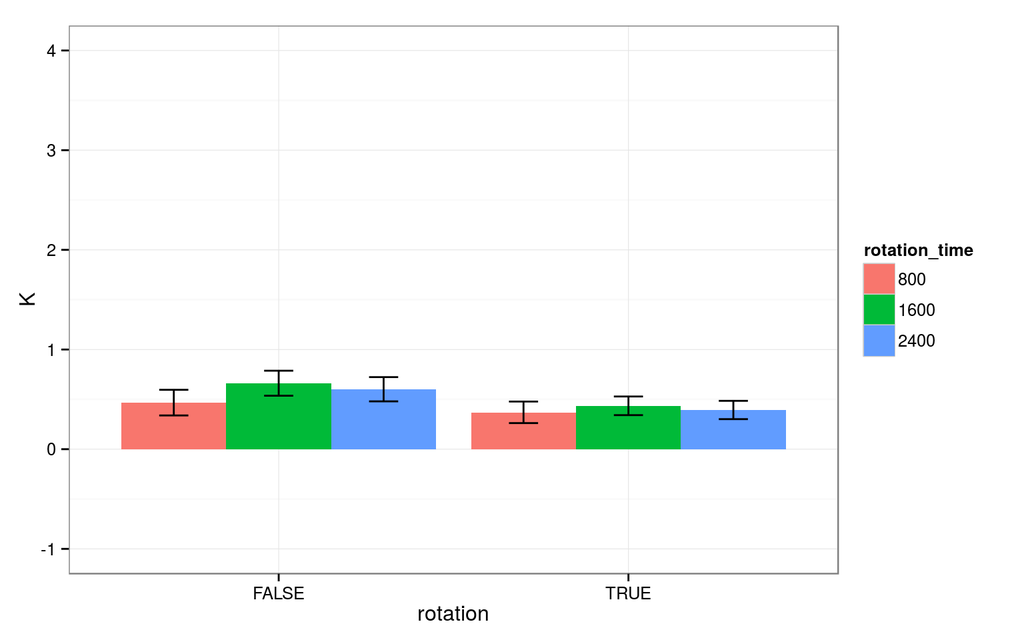

This plot is the same as the plot of the main result, except split by the time the object was hidden, to show any potential effects of how long the object must be mentally rotated or held in memory. We did not replicate the original results in this analysis either, and we do not even appear to have the same trends as they did.

## Exploratory analyses

### Distribution of capacity estimates

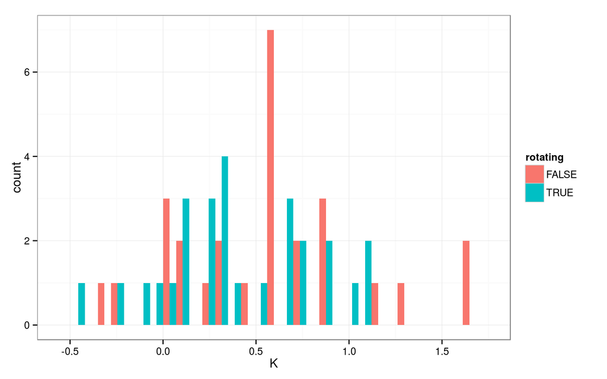

### Results with capacities clipped at zero

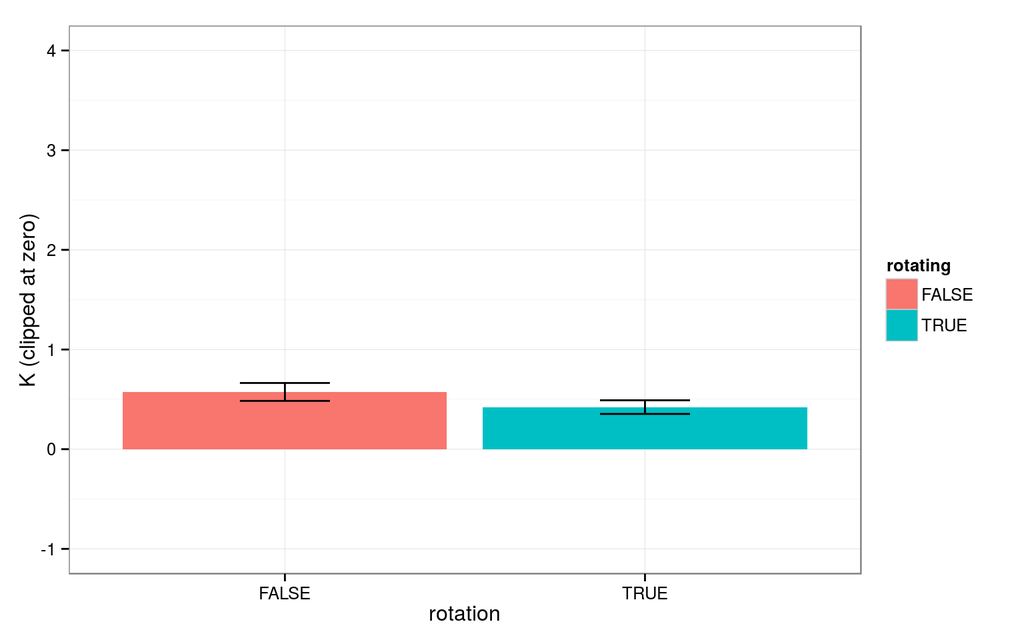

$F(1,26) = 3.7553735, p = 0.0635701$

Still cannot reject the null even if we assume the original authors clipped capacity at 0.

### Accuracy by condition:

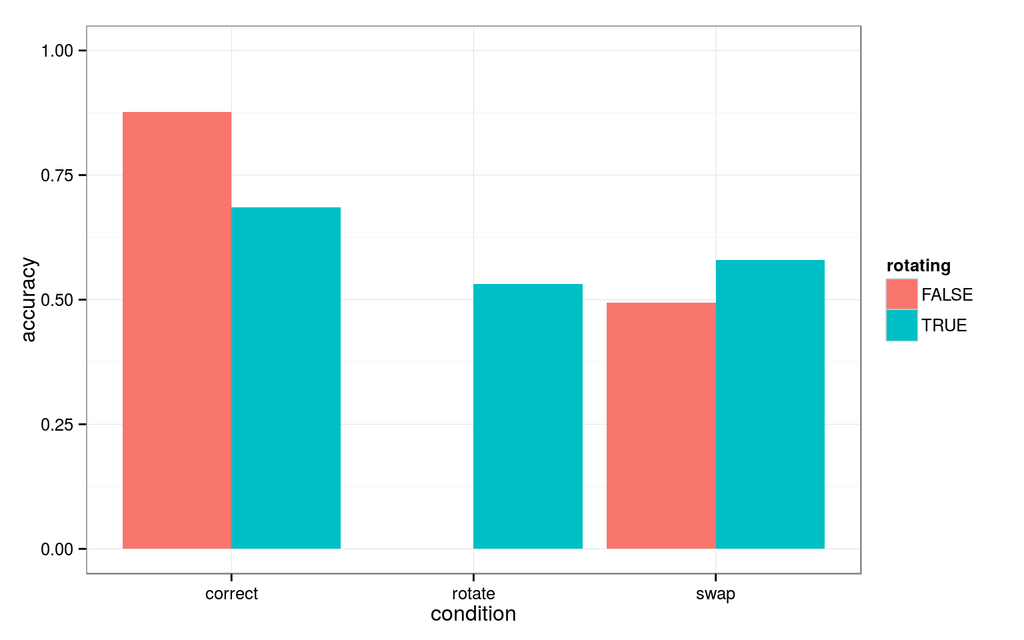

### Error checking our experiment setup

The object was positioned correctly and did not change on the ‘correct’ trials

```
## [1] TRUE
```

The object was positioned correctly and did change on the ‘swap’ trials

```
## [1] TRUE
```

The object was positioned incorrectly and did not change on the ‘rotate’ trials.

```
## [1] TRUE
```

It does not appear that there was any problem with our experimental code.

## Conclusions

We were unable to replicate the original result. This could perhaps simply be due to an overestimated effect size in the original paper which caused us to underpower our sample, because our results were in the same direction as the original study and trending towards significance. However, even if that is the case, our capacity estimates were much lower than the original authors, which suggests some qualitative difference. This may be an effect of running the study on Amazon Mechanical Turk, or of the longer task in the original study, which may have allowed participants to learn the task more thoroughly and perform better towards the end. Further research and meta-analysis is needed to fully evaluate this effect.

## Notes

After data collection, we discovered an error in our pre-registered analysis code, from testing we had retained

substr(as.character(experiment_data$response_mappings[1]),1,7) == ‘correct’

instead of the correct

substr(as.character(experiment_data$response_mappings),1,7) == ‘correct’

This meant that all subjects results were computed as though they had the first subjects response key mapping (response keys were counterbalanced across participants). We have corrected this code in this writeup.

We also noted that our accuracy based secondary analysis was comparing accuracy in the ‘correct’ condition rather than the ‘swap’ condition, and corrected this code in this writeup.